# StockResearch

Gabriel Foix

2021-03-04

Buy Quality at the a good momentum and get rid of the fishy stocks on time. That's all.

### Define candidates

Download all info needed applying the following filters:

### Factor 1: Quality

1. Healthy debts: A company shoud generate cash in order to repay its debt. The **Free Cash Flow to Debt** ratio is a good indicator of how quick a company pays back its debt. The lower this ratio the better.

FCF2D = $\frac{Debt}{Free Cash Flow}$

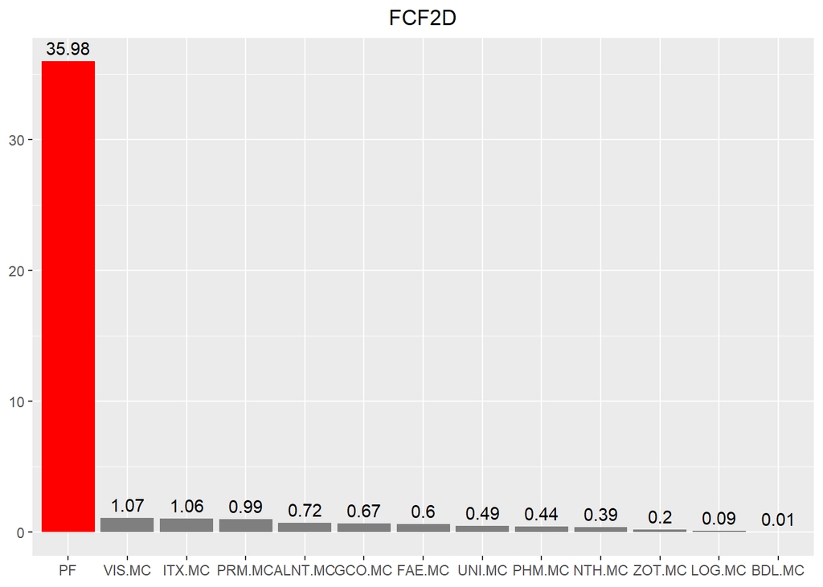

2. Profitability: ROA

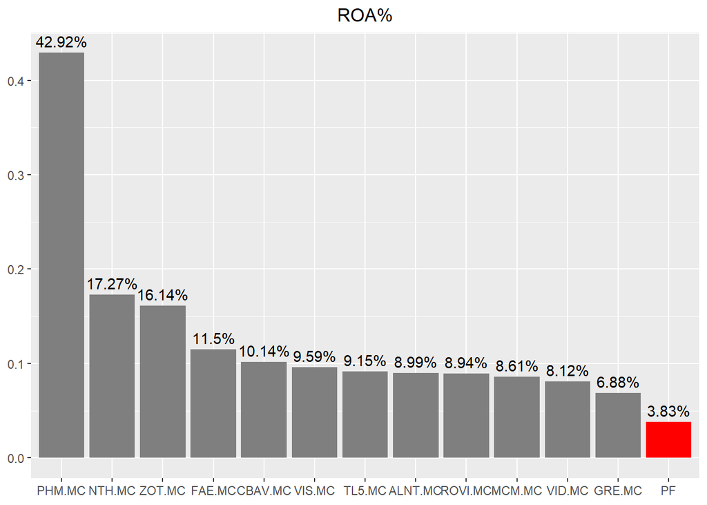

3. High Margin: We look for companies that generate free cash flow compare to its price. The **Free Cash Flow to Entreprise Value** ratio tells us how many years of cash flow would be needed to the return the 100% of the investment. Again, the lower, the better. Values bellow 1 would mean "free lunch".

FCF2EV = $\frac{EV}{Free Cash Flow}$

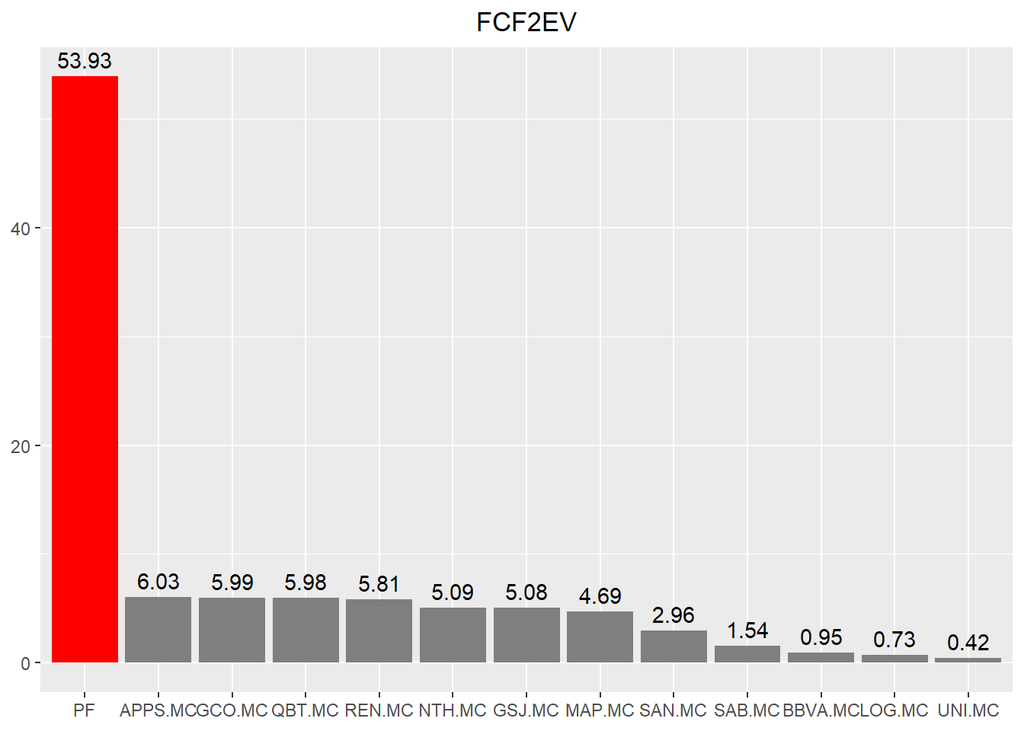

#### Download Historical Data

Download only stocks not filtered previously

### Value touch

Filter out stocks with PER > 40

Report Candidates

Filter Summary

| Filter | NStocks |
| --- | --- |
| Initial | 128 |
| ROA | 128 |
| FCF | 128 |
| Hist1Y | 128 |
| PER | 128 |

### Factor 2: Momentum

Don't hold onto a stock simply because it is high quality. So called quality stocks have cycles too. Stan Weinstein (page 177)

Generic Intermediate-Term Momentum Based on Gray-Vogel (page 80)

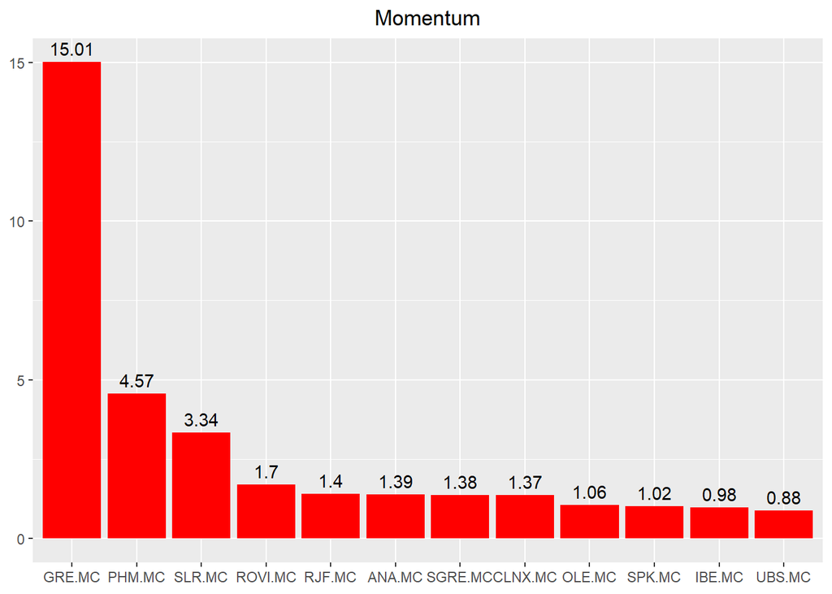

### Factor 3: Timing Signal

Sell Signal - Pr < 1% SMA 30 weeks and slope negative (< -0.2)  
Buy Signal - 109% * SMA30 < Pr > SMA 30 and slope positive (> 0.2)  
Hold Signal - Neither Buy nor Sell

#### Calc Market Cap

Using free float shares

### Summary

Summary

| Ticker | Signal | Quality | Momentum | Final_rank | PER | MCap |
| --- | --- | --- | --- | --- | --- | --- |
| PHM.MC | BUY | 121.0 | 122 | 128.0 | 13.7650198 | 1464503002 |
| CASH.MC | NA | 109.0 | 124 | 127.0 | 0.0000000 | 0 |
| NTGY.MC | HOLD | 124.0 | 102 | 126.0 | 20.2531638 | NA |
| CBAV.MC | HOLD | 114.0 | 108 | 124.0 | 17.0700632 | 22699934 |
| VIS.MC | HOLD | 127.0 | 94 | 122.0 | 22.2648752 | NA |
| OLE.MC | HOLD | 105.0 | 115 | 119.5 | 1.0706896 | 55849635 |
| FAE.MC | HOLD | 107.0 | 103 | 118.0 | 13.8022818 | 994687067 |
| PRM.MC | BUY | 123.0 | 84 | 117.0 | 25.1250005 | 44622976 |
| LOG.MC | HOLD | 113.0 | 93 | 115.5 | 13.1305041 | 1086935641 |
| ELE.MC | SELL | 101.0 | 104 | 114.0 | 15.8257571 | 6545179321 |
| VID.MC | BUY | 103.0 | 99 | 112.0 | 17.1352319 | 1736526146 |
| GSJ.MC | HOLD | 92.0 | 107 | 110.0 | 16.2571430 | 126095460 |
| ALNT.MC | HOLD | 117.0 | 76 | 109.0 | 17.5999997 | 228982020 |
| BDL.MC | HOLD | 110.0 | 81 | 108.0 | 21.4007782 | 30077520 |
| APPS.MC | HOLD | 120.0 | 58 | 107.0 | -8.1126127 | 1283579884 |
| APAM.MC | HOLD | 90.5 | 87 | 106.0 | 15.7579901 | 1625046695 |
| GCO.MC | HOLD | 104.0 | 71 | 104.5 | 14.6171175 | 1322247677 |
| ZOT.MC | HOLD | 119.0 | 56 | 104.5 | 18.6333338 | 1007932972 |
| ROVI.MC | HOLD | 51.5 | 120 | 101.0 | 39.0199637 | 860449264 |
| CCEP.MC | HOLD | 69.0 | 100 | 100.0 | 39.1743126 | 8671513508 |
| EBRO.MC | HOLD | 80.5 | 83 | 95.5 | 13.8768990 | 750364431 |
| SGRE.MC | BUY | 46.5 | 117 | 95.5 | -26.3206669 | 6323473000 |
| BKT.MC | HOLD | 112.0 | 51 | 94.0 | 16.9393944 | 3555485571 |
| VER.MC | HOLD | 77.5 | 82 | 93.0 | 9.0406323 | NA |
| ANA.MC | HOLD | 41.0 | 118 | 91.0 | 18.1061689 | 2976533188 |
| AZK.MC | HOLD | 102.0 | 57 | 91.0 | 22.0769222 | 49164527 |
| LGT.MC | HOLD | 115.0 | 44 | 91.0 | 20.1342282 | 87448800 |
| ALB.MC | HOLD | 95.5 | 63 | 89.0 | 27.0448549 | NA |
| NTH.MC | HOLD | 126.0 | 30 | 87.0 | 12.3825505 | 25492651 |
| EKT.MC | HOLD | 50.0 | 105 | 85.0 | 19.2272728 | 1021080551 |

[output cut: 71 more lines]

Save output in template